# Prediction of House Prices In King County, Washington Using Regression Models

Omar Choudhry

oachoud2

Abstract

In this project I will be using a dataset that describes houses in King County, Washington. I am attempting to predict the price of the house using various attributes of the house such as square footage, condition, and age. This is useful because it will be able to determine wether or not a house is listed at an appropriate price. I fit numerous Linear and KNN Regression models to find the model that best predicts price. Using the Test RMSE I found that a linear interaction model did the best job in predicting the price of a house in King County. This gave me a good model to apply to my problem, being able to list and buy houses at fair prices, so that both parties are sure they are getting a good deal.

## Introduction

Below is some exploratory analysis of my data set.

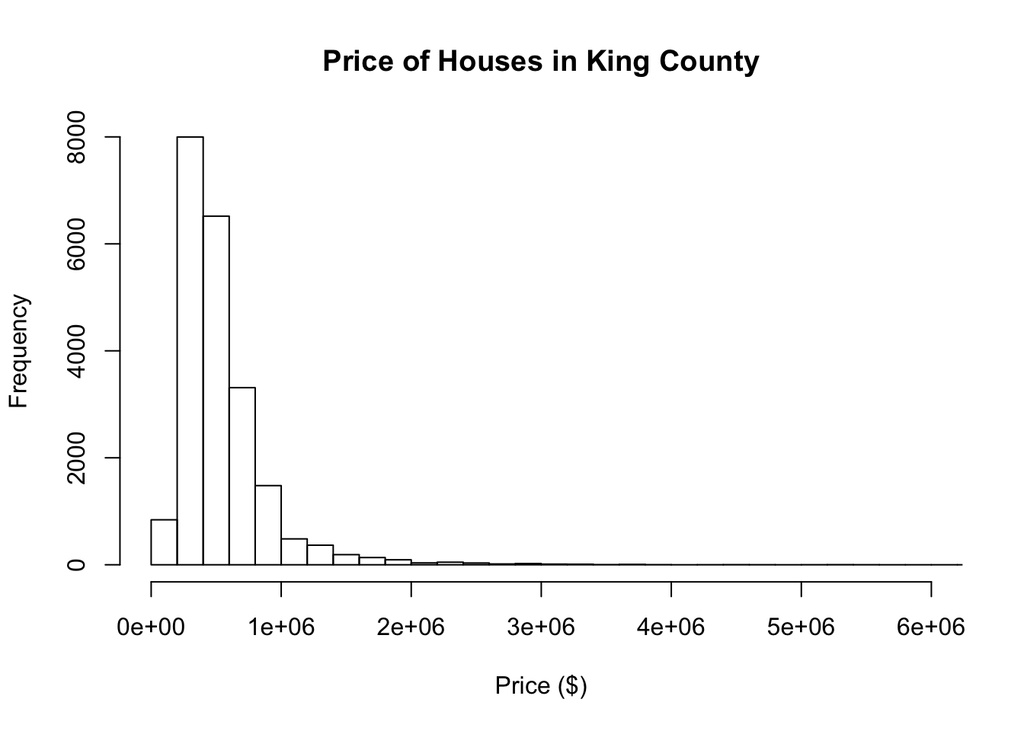

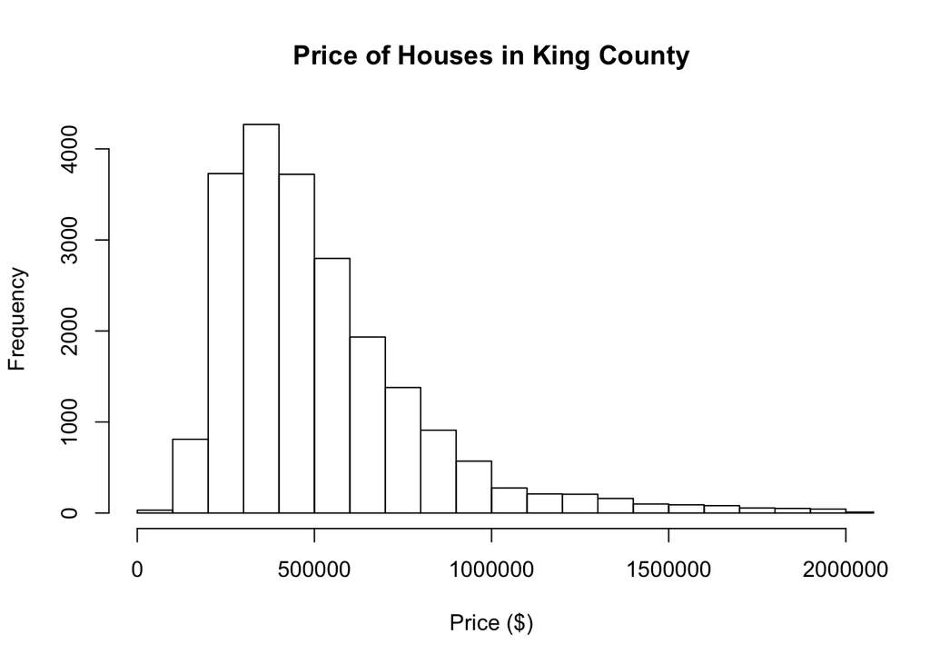

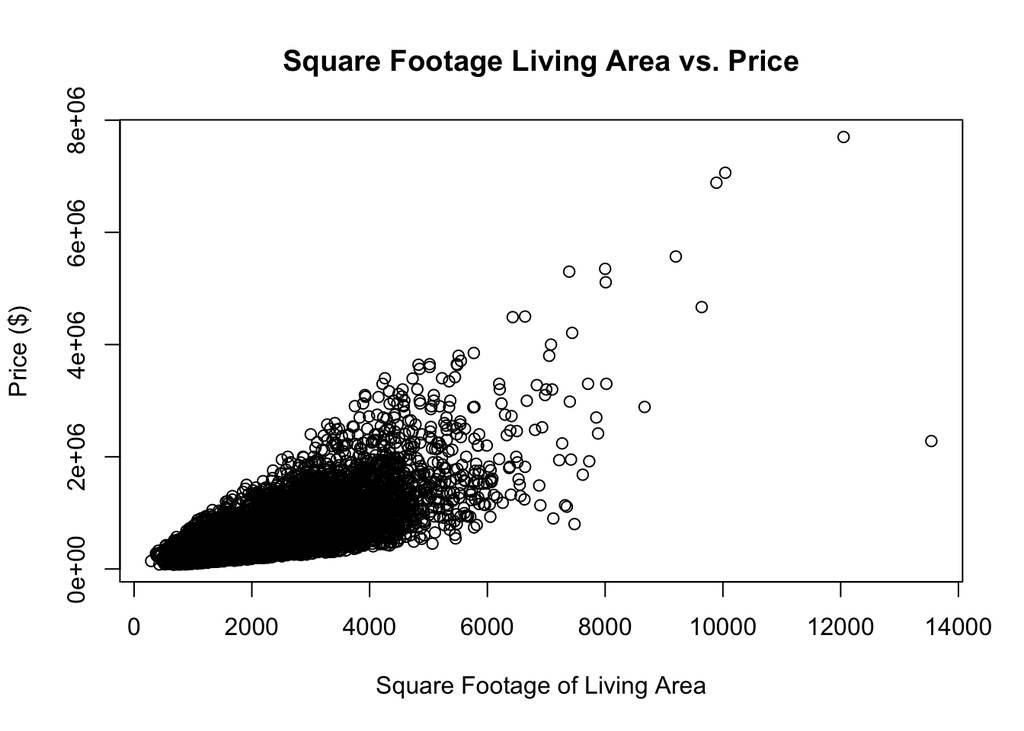

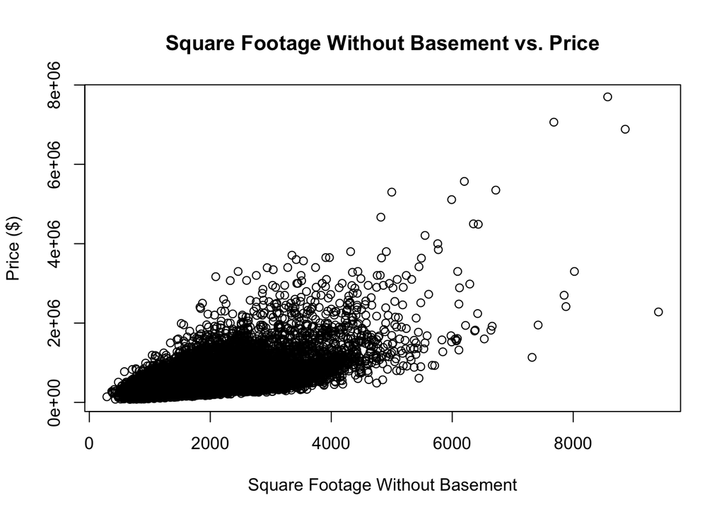

## Methods

In order to find the model that best predicts price based on the house attributes I trained both linear regression, and K-Nearest Neighbor Models. This involved many steps that I have broken down below. The goal of training multiple models of each type was to find the model with the lowest test Root Mean Squared Error. This model will do the best job at predicting the price of a house in King County based on the attributes we included.

### Data

For purposed of my analysis I decided to drop both the ID and Date variables, as they do not directly relate to how much a house costs. There were a few other variables in question, so I did some testing when training models to see if I should alter or drop them. The variables in question included zip code, latitude, longitude, and square footage variables. Specifically, I wanted to check if zip code was better as a categorical variable, if latitude and longitude are significant at all, and if the square footage variables have any interaction that would skew the model.

```r
#Reading Data
data = read.csv("https://daviddalpiaz.github.io/stat432sp18/projects/kc_house_data.csv")
#drop ID and Date Variables
data = data[-1:-2]
```

| Variable | Issue | Test | Solution |
| --- | --- | --- | --- |
| Zipcode | Not Categorical | Refactor and check RMSE | Refactor in Dataset |
| Lat/Long | May not be Significant | Check Significance via Summary | Do Not Remove |
| Square Footage | Possible Interactions | Check RMSE with Interactions | Fit With Interaction |

After finalizing the dataset I will be using to train the models, I split the data into a training set and a testing set. I used 80 percent of the data to train my models, and 20 percent to test them.

```r
#Test-Train Split
set.seed(1)
dataidx  = sample(nrow(data), size = trunc(0.80 * nrow(data)))
trn = data[dataidx, ]
tst = data[-dataidx, ]
```

### Models

I built 21 models in total 5 of them being linear, and 16 being K nearest-neighbor regression models. I will provide a detailed list of these in the following 2 sections. For every model I will obtain the test RMSE and use that to evaluate the accuracy.

#### Linear

```r
#Linear Models
#solutions for zipcode
lmod1 = lm(price ~ .,  data = trn)
lmod2 = lm(price ~ .-zipcode + as.factor(zipcode),  data = trn)
lmod3 = lm(price ~ .-zipcode,  data = trn)
```

```r
lmod4 = lm(price ~ . + (sqft_living*sqft_lot) + (sqft_living*sqft_above)+ (sqft_living*sqft_basement)+ (sqft_living*sqft_living15)+ (sqft_living*sqft_lot15)+ (sqft_lot15*sqft_lot) + (sqft_lot*sqft_above) + (sqft_lot*sqft_basement),  data = trn)
null=lm(price~1, data=trn)
lmod5 = step(null, scope = list(upper=lmod1), data=trn, direction="both")
```

Models Fitted Above:

1. Full Additive Model
2. Full Additive Model with Zipcode Factored
3. Full Additive Model -Zipcode
4. Square Foot Interaction Model
5. Stepwise Model

#### K-Nearest Neighbors

```r
unscaledKNN = train(
  price ~ .,
  data = trn,
  trControl = trainControl(method = "cv", number = 5),
  method = "knn",
  tuneGrid = expand.grid(k = c(1, 5, 10, 15, 20, 25, 30, 35))
)

scaledKNN = train(
  price ~ .,
  data = trn,
  trControl = trainControl(method = "cv", number = 5),
  preProcess = c("center", "scale"),
  method = "knn",
  tuneGrid = expand.grid(k = c(1, 5, 10, 15, 20, 25, 30, 35))
)
```

For K-Nearest Neighbors I utilized 2 types of models:

1. KNN with no pre-processing
2. KNN where variables are centered and scaled (Mean=0 and Variance=1)

For both methods I used 8 values for the k parameter (1, 5, 10, 15, 20, 25, 30, 35). This resulted in 16 KNN Models.

## Results

After determining the Test RMSE of the 21 models, and comparing them, we are able to narrow it down to a single best model for predicting house price from the included attributes.

[output not shown]

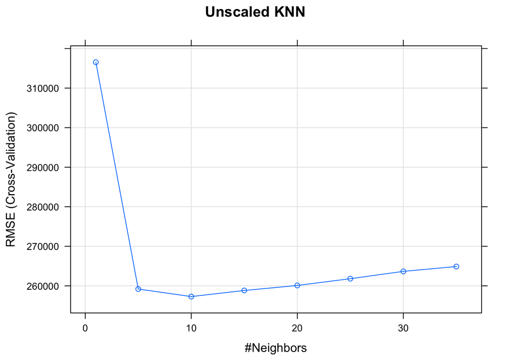

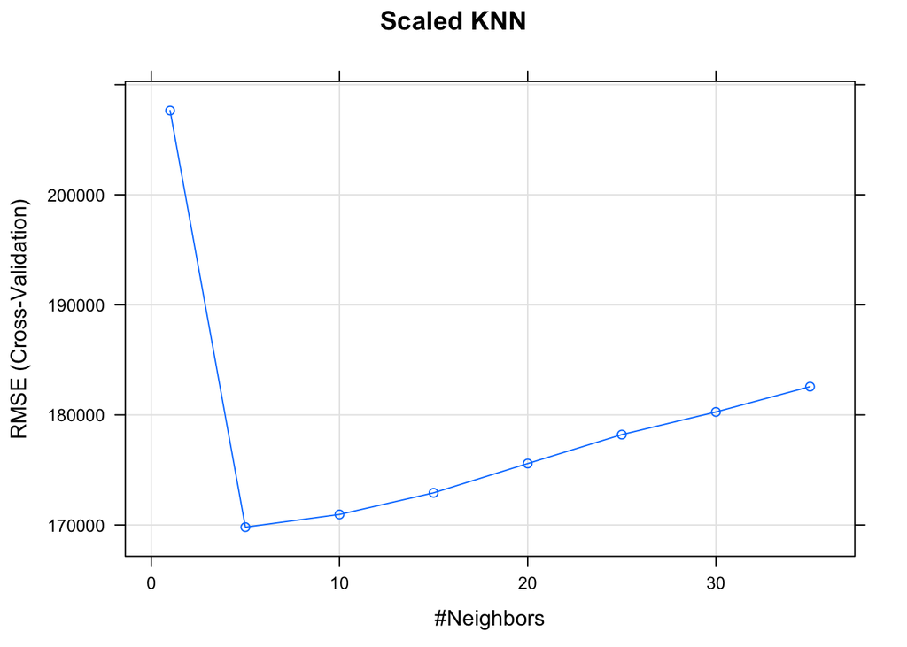

| Method | CV RMSE | Test RMSE |
| --- | --- | --- |
| Unscaled KNN | 257287 | 259768 |
| Scaled KNN | 169801 | 164444 |

## Discussion

Because we have determined that the Square Foot Interaction Linear Model is best for predicting house prices in King County, Washington, we can deduce a few things.

1. The Zipcode that the house is located in should be treated as a category, and not as a numeric value
2. The square footage of the living space as well as the square footage of the lot and basement are very correlated, and accounting for their interactions makes our model much more accurate.

Final Model:

```r
lmod4
```

```
##
## Call:
## lm(formula = price ~ . + (sqft_living * sqft_lot) + (sqft_living *
##     sqft_above) + (sqft_living * sqft_basement) + (sqft_living *
##     sqft_living15) + (sqft_living * sqft_lot15) + (sqft_lot15 *
##     sqft_lot) + (sqft_lot * sqft_above) + (sqft_lot * sqft_basement),
##     data = trn)
##
## Coefficients:
##               (Intercept)                   bedrooms
##                -2.944e+07                 -7.299e+03
##                 bathrooms                sqft_living
##                 2.784e+04                 -7.677e+01
##                  sqft_lot                     floors
##                 6.297e-01                 -3.059e+04
##                waterfront                       view
##                 5.905e+05                  5.160e+04
##                 condition                      grade
##                 3.216e+04                  6.271e+04
##                sqft_above              sqft_basement
##                 4.841e+01                         NA
##                  yr_built               yr_renovated
##                -5.512e+02                  2.171e+01
##              zipcode98002               zipcode98003
##                 2.703e+04                 -2.859e+04
##              zipcode98004               zipcode98005
##                 7.046e+05                  2.782e+05
##              zipcode98006               zipcode98007
##                 2.224e+05                  2.218e+05
##              zipcode98008               zipcode98010
##                 2.241e+05                  1.050e+05
##              zipcode98011               zipcode98014
##                 7.807e+04                  1.307e+05
##              zipcode98019               zipcode98022
##                 8.506e+04                  2.888e+04
##              zipcode98023               zipcode98024
##                -5.616e+04                  1.920e+05
##              zipcode98027               zipcode98028
##                 1.763e+05                  6.472e+04
##              zipcode98029               zipcode98030
```

[output cut: 50 more lines]

```
##                 4.321e+03                 -1.939e+04
##              zipcode98199                        lat
##                 3.166e+05                  1.469e+05
##                      long              sqft_living15
##                -1.897e+05                 -8.393e+00
##                sqft_lot15       sqft_living:sqft_lot
##                 1.019e+00                 -6.840e-04
##    sqft_living:sqft_above  sqft_living:sqft_basement
##                 3.204e-02                  3.274e-02
## sqft_living:sqft_living15     sqft_living:sqft_lot15
##                 1.402e-02                 -4.417e-04
##       sqft_lot:sqft_lot15        sqft_lot:sqft_above
##                 1.309e-06                  5.353e-04
##    sqft_lot:sqft_basement
##                        NA
```

Each of the coefficients listed above describes how much an attribute of a house should be multiplied by when making price predictions. For example the coefficient for sqft_lot is 0.6297. This means that the square footage of the lot of the given house we are making a prediction for will be multiplied by this value, and then added to the sum of the rest of the coefficients times their corresponding attributes. This summation of (coefficients * attributes) is what determines the price of the house.

From this model I could take a new house that was listed on the market in King County, gather the attributes that are apart of my model, plug them in, and return a predicted price for that house. If I were in the market to buy a house, this would be very helpful in deciding whether or not I am getting a good deal. If I am a realtor in the market, this model would be helpful in picking starting price for the house.

## Appendix

#### Additional Code

```r
library(caret)
library(randomForest)
library(tidyverse)
library(knitr)
library(kableExtra)

calc_rmse = function(actual, predicted) {
  sqrt(mean((actual - predicted) ^ 2))
}

get_best_result = function(caret_fit) {
  best = which(rownames(caret_fit$results) == rownames(caret_fit$bestTune))
  best_result = caret_fit$results[best, ]
  rownames(best_result) = NULL
  best_result
}

modlist1 = list(lmod1,lmod2,lmod3)
trnpred1 = lapply(modlist1, predict, newdata = trn)
tstpred1 = lapply(modlist1, predict, newdata = tst)

# get RMSEs
trnrmse1 = sapply(trnpred1, calc_rmse, actual = trn$price)
tstrmse1 = sapply(tstpred1, calc_rmse, actual = tst$price)

modlist2 = list(lmod4,lmod5)
trnpred2 = lapply(modlist2, predict, newdata = trn)
tstpred2 = lapply(modlist2, predict, newdata = tst)

# get RMSEs
trnrsme2 = sapply(trnpred2, calc_rmse, actual = trn$price)
tstrmse2 = sapply(tstpred2, calc_rmse, actual = tst$price)
```

#### Zipcode Refactoring

| Model | Train RMSE | Test RMSE |
| --- | --- | --- |
| Full Model | 200793 | 203096 |
| factor Zipcode | 159749 | 165437 |
| Without Zipcode | 202152 | 204890 |

We see that factoring zipcode is very useful in lowering RMSE.

#### Lat and Long are Significant

```r
summary(lmod1)
```

```
##
## Call:
## lm(formula = price ~ ., data = trn)
##
## Residuals:
##      Min       1Q   Median       3Q      Max
## -1243444   -98461    -9726    77608  4376540
##
## Coefficients: (1 not defined because of singularities)
##                 Estimate Std. Error t value Pr(>|t|)
## (Intercept)    4.873e+06  3.283e+06   1.484  0.13778
## bedrooms      -3.455e+04  2.090e+03 -16.530  < 2e-16 ***
## bathrooms      3.833e+04  3.620e+03  10.591  < 2e-16 ***
## sqft_living    1.457e+02  4.903e+00  29.722  < 2e-16 ***
## sqft_lot       1.748e-01  5.463e-02   3.200  0.00138 **
## floors         3.596e+03  4.013e+03   0.896  0.37022
## waterfront     5.327e+05  1.970e+04  27.047  < 2e-16 ***
## view           5.621e+04  2.391e+03  23.508  < 2e-16 ***
## condition      2.756e+04  2.626e+03  10.496  < 2e-16 ***
## grade          9.437e+04  2.399e+03  39.346  < 2e-16 ***
## sqft_above     3.308e+01  4.871e+00   6.792 1.14e-11 ***
## sqft_basement         NA         NA      NA       NA
## yr_built      -2.522e+03  8.110e+01 -31.094  < 2e-16 ***
## yr_renovated   1.990e+01  4.075e+00   4.883 1.05e-06 ***
## zipcode       -5.646e+02  3.685e+01 -15.320  < 2e-16 ***
## lat            6.016e+05  1.198e+04  50.218  < 2e-16 ***
## long          -2.142e+05  1.478e+04 -14.493  < 2e-16 ***
## sqft_living15  2.522e+01  3.862e+00   6.531 6.73e-11 ***
## sqft_lot15    -3.928e-01  8.232e-02  -4.772 1.84e-06 ***
## ---
## Signif. codes:  0 '***' 0.001 '**' 0.01 '*' 0.05 '.' 0.1 ' ' 1
##
## Residual standard error: 200900 on 17272 degrees of freedom
## Multiple R-squared:  0.6955, Adjusted R-squared:  0.6952
## F-statistic:  2321 on 17 and 17272 DF,  p-value: < 2.2e-16
```

We see that latitude and longitude are significant variables.